# **Exploring the Effect Natural Disasters have on the Economy**

By : Riya Kumari

Table of Contents:

- Introduction
- Data Collection and Processing
- Data Exploration
- Linear Regression and Hypothesis Testing
- Conclusion

# **Introduction**

With climate change on the rise, the predictability of natural disasters has been quite challenging and their occurrences are on the rise. 2020 was a disastrous year as we saw many natural disasters like wildfires, hurricanes, rain ,and flooding all around the US. The impact of these disasters are devastating. They kill hundreds of people and destroy thousands of homes. People's lives are shaken up, they lose their livelihoods and businesses go under. An example of this is Merced Property & Casualty Co, an insurance company that was unable to payout those who had lost their homes because of the large number of homeowner policies who were affected by a wildfire.

[figure not shown]

image credit : https://www.climate.gov/media/11835

With an increasing number of natural disasters, we are starting to face larger economic losses. In the image above, we can see just how costly these disasters can be. But how might natural disasters affect the economy on a much larger scale and in the long term? Does it differ by state or country? This is our starting question that we will try to explore in this tutorial.

Moreover, will be focusing on two countries, US and Indonesia, and do an in-depth analysis on different US states. The reason I choose Indonesia is because it is a much smaller country than the US and it is also near the ring of fire which makes it prone to natural disasters. It will be interesting to compare effect of natural disasters in Indonesia to the US because of the differences between the two countries.

# **Getting Started with the Data**

When a disaster occurs, it is declared by the Federal Emergency Management Agency (FEMA). FEMA helps people before, during, and after disasters. They have made some of their datasets public through multiple APIs that can be found on this page : https://www.fema.gov/about/openfema/data-sets. After reading through the descriptions of these datasets, we choose to move forward with their FemaWebDisasterDeclarations as it contains necessary information on when, where and what type of disaster took place.

### **IMPORTS**

```python
import numpy as np
import pandas as pd
import requests
import matplotlib.pyplot as plt
import seaborn as sns
from sklearn.linear_model import LinearRegression
import warnings
from pandas.core.common import SettingWithCopyWarning
```

### **EXTRACTING FEMA DATA**

```python
# Reading the dataset as a pandas dataframe
fema_data = pd.read_csv("https://www.fema.gov/api/open/v1/FemaWebDisasterDeclarations.csv")
fema_data.head(5)
```

|  | disasterNumber | declarationDate | disasterName | incidentBeginDate | incidentEndDate | declarationType | stateCode | stateName | incidentType | entryDate | updateDate | closeoutDate | hash | lastRefresh | id |
| --- | --- | --- | --- | --- | --- | --- | --- | --- | --- | --- | --- | --- | --- | --- | --- |
| 0 | 3397 | 2018-02-11T00:00:00.000Z | TROPICAL STORM GITA | 2018-02-07T00:00:00.000Z | 2018-02-12T00:00:00.000Z | Emergency | AS | American Samoa | Hurricane | 2018-02-11T00:00:00.000Z | 2018-09-26T00:00:00.000Z | NaN | 0d548a11763653005b93ff0697cacdc6bc9c9cce | 2021-07-13T23:01:15.083Z | 5aa2d570cb4f0f7020b1703a |
| 1 | 3390 | 2017-09-18T00:00:00.000Z | HURRICANE MARIA | 2017-09-16T00:00:00.000Z | 2017-09-22T00:00:00.000Z | Emergency | VI | Virgin Islands of the U.S. | Hurricane | 2017-09-18T00:00:00.000Z | 2018-09-07T00:00:00.000Z | 2018-09-07T00:00:00.000Z | 2f759fed8f206694f47538ffda1be535c6aa234f | 2021-07-13T23:01:15.162Z | 5aa2d570cb4f0f7020b1703f |
| 2 | 4352 | 2017-12-20T00:00:00.000Z | SEVERE STORMS AND FLOODING | 2017-10-04T00:00:00.000Z | 2017-10-06T00:00:00.000Z | Major Disaster | NM | New Mexico | Flood | 2017-12-21T00:00:00.000Z | 2017-12-21T00:00:00.000Z | NaN | 9426023f5a3c2be37671a5bb498848756552c2a4 | 2021-07-13T23:01:15.087Z | 5aa2d570cb4f0f7020b1703b |
| 3 | 3388 | 2017-09-08T00:00:00.000Z | HURRICANE IRMA | 2017-09-04T00:00:00.000Z | 2017-10-04T00:00:00.000Z | Emergency | FL | Florida | Hurricane | 2017-09-09T00:00:00.000Z | 2018-04-03T00:00:00.000Z | 2018-03-28T00:00:00.000Z | 0302a9f6b2dcbec3c243c6f03807b733d263983f | 2021-07-13T23:01:15.173Z | 5aa2d570cb4f0f7020b17040 |
| 4 | 3395 | 2017-10-08T00:00:00.000Z | HURRICANE NATE | 2017-10-07T00:00:00.000Z | 2017-10-11T00:00:00.000Z | Emergency | FL | Florida | Hurricane | 2017-10-08T00:00:00.000Z | 2017-10-13T00:00:00.000Z | NaN | 8e70993c0499f478a5db4b69e761d53db128ea87 | 2021-07-13T23:01:15.114Z | 5aa2d570cb4f0f7020b1703d |

There are many colums in the FemaWebDisasterDeclaration dataset. The ones that I am intesrested in are the following:

- incidentType : describes the type of incident (Hurricane, Flood, Snow, Wildfire, etc)
- declarationDate : date the disaster was declared
- incidententBeginDate : date the disaster began
- incidentEndDate : date the disaster ended
- declarationType : defines whether the disaster is a "Major Disaster", "Emergency", etc.
- state

Looking at just the five rows of the dataframe, I notice some missing values which are labeled as NaN. There can be more missing values so lets try to find which columns have missing data so we can handle them appropriately.

```python
# Looping through each column in fema dataframe
for column in fema_data:

  # Counting number of null values
  if fema_data[column].isnull().sum() > 0:
    print("percent of missing values for " + column + ": " + str(fema_data[column].isnull().sum()/fema_data[column].count().sum()))
```

```
percent of missing values for incidentEndDate: 0.10744781783681215
percent of missing values for closeoutDate: 0.25849056603773585
```

We notice that only two columns have missing data : incidentEndDate and closeoutDate. Because these are date columns that record a specific event in time, it would not be appropriate to approximate these values. Therefore, we will replace these with an arbitrary date value such as 1000-04-20 00:00:00+00:00. I cannot just replace with np.nan because we will be converting the date objects to datetime objects for easier data processing and np.nan creates type issues.

```python
# Converting dates to dateTime objects for easier processing and analysis
fema_data['declarationDate'] = pd.to_datetime(fema_data['declarationDate'])
fema_data['incidentBeginDate'] = pd.to_datetime(fema_data['incidentBeginDate'])
fema_data['incidentEndDate'] = pd.to_datetime(fema_data['incidentEndDate'])
fema_data['entryDate'] = pd.to_datetime(fema_data['entryDate'])
fema_data['updateDate'] = pd.to_datetime(fema_data['updateDate'])
fema_data['closeoutDate'] = pd.to_datetime(fema_data['closeoutDate'])
fema_data['lastRefresh'] = pd.to_datetime(fema_data['lastRefresh'])

# Replacing the null values and fixing types
fema_data = fema_data.fillna(value = np.datetime64('1000-04-20 00:00:00+00:00'))
```

Now we will add a year column to the dataframe so we can analyze disasters based on the year they occured in.

```python
# Creating a year column
years = pd.DatetimeIndex(fema_data['incidentBeginDate']).year
fema_data.insert(0, "year", years)
```

Lets look at the types of disasters and how frequently they occur to get an idea of what kind of data we might want to be looking at.

```python
fema_data['incidentType'].value_counts()
```

```
Fire                1532
Severe Storm(s)     1010
Flood                849
Hurricane            425
Tornado              177
Snow                 168
Biological           167
Severe Ice Storm      74
Typhoon               63
Drought               46
Earthquake            35
Coastal Storm         31
Other                 30
Freezing              18
Mud/Landslide          8
Toxic Substances       8
Dam/Levee Break        6
Volcano                6
Fishing Losses         6
Human Cause            4
Tsunami                3
Terrorist              2
Chemical               1
Name: incidentType, dtype: int64
```

I wonder if the biological event is Covid, if it is then we can go on and remove it from the dataset as we are trying to look at natural disasters that are weather-based.

```python
fema_data[fema_data['incidentType'] == "Biological"].head(5)
```

|  | year | disasterNumber | declarationDate | disasterName | incidentBeginDate | incidentEndDate | declarationType | stateCode | stateName | incidentType | entryDate | updateDate | closeoutDate | hash | lastRefresh | id |
| --- | --- | --- | --- | --- | --- | --- | --- | --- | --- | --- | --- | --- | --- | --- | --- | --- |
| 4206 | 2020 | 3429 | 2020-03-13 00:00:00+00:00 | COVID-19 | 2020-01-20 00:00:00+00:00 | 1000-04-20T00:00:00 | Emergency | OR | Oregon | Biological | 2020-03-14 00:00:00+00:00 | 2020-10-14 00:00:00+00:00 | 2020-10-13 00:00:00+00:00 | 8bc5d6f8570500a629b1524f182ff5c44ad6ee07 | 2021-07-13 23:01:14.636000+00:00 | 5e6d89b9c101911ebd78a85d |
| 4207 | 2020 | 3427 | 2020-03-13 00:00:00+00:00 | COVID-19 | 2020-01-20 00:00:00+00:00 | 1000-04-20T00:00:00 | Emergency | WA | Washington | Biological | 2020-03-14 00:00:00+00:00 | 2021-09-28 00:00:00+00:00 | 2021-09-15 00:00:00+00:00 | 3b38493413ddae0dea488adc2b24982754d4bf37 | 2021-09-28 12:42:47.551000+00:00 | 5e6d89b9c101911ebd78a85f |
| 4208 | 2020 | 3428 | 2020-03-13 00:00:00+00:00 | COVID-19 | 2020-01-20 00:00:00+00:00 | 1000-04-20T00:00:00 | Emergency | CA | California | Biological | 2020-03-14 00:00:00+00:00 | 2020-03-14 00:00:00+00:00 | 1000-04-20T00:00:00 | d50ad5ef8888291c3745d97f7db275ccfbb22e1c | 2021-07-13 23:01:14.637000+00:00 | 5e6d89b9c101911ebd78a85e |
| 4209 | 2020 | 3430 | 2020-03-13 00:00:00+00:00 | COVID-19 | 2020-01-20 00:00:00+00:00 | 1000-04-20T00:00:00 | Emergency | MD | Maryland | Biological | 2020-03-15 00:00:00+00:00 | 2020-09-30 00:00:00+00:00 | 2020-09-30 00:00:00+00:00 | 4ebd874ceedff70c180d80c55f6ce2f1f60661da | 2021-07-13 23:01:14.635000+00:00 | 5e6e3b3ec101911ebd6bcde9 |
| 4210 | 2020 | 3433 | 2020-03-13 00:00:00+00:00 | COVID-19 | 2020-01-20 00:00:00+00:00 | 1000-04-20T00:00:00 | Emergency | VI | Virgin Islands of the U.S. | Biological | 2020-03-15 00:00:00+00:00 | 2020-09-28 00:00:00+00:00 | 2020-09-28 00:00:00+00:00 | e3e54654479ced2cb081479926a86699e6b72fe2 | 2021-07-13 23:01:14.633000+00:00 | 5e6e3feac101911ebd6befab |

```python
# Removing biological data
fema_data = fema_data[fema_data['incidentType'] != 'Biological']
```

It might be easier to also just look at the top 10 disaster types so lets create a dataframe with data on only the top 10 disaster types.

```python
# Retreiving the top 10 disaster types
top_10_disasterTypes = fema_data['incidentType'].value_counts()
top_10_disasterTypes = top_10_disasterTypes.head(10)
top_10_disasterTypes = top_10_disasterTypes.reset_index()
top_10_disasterTypes = top_10_disasterTypes.rename({'index': 'incidentType', 'incidentType': 'occurence'}, axis=1)

# Creating dataframe with data on the top 10 disaster types
top_10_disastersData = fema_data[fema_data['incidentType'].isin(top_10_disasterTypes['incidentType'])]

print(top_10_disasterTypes)
top_10_disastersData.head(3)
```

```
       incidentType  occurence
0              Fire       1532
1   Severe Storm(s)       1010
2             Flood        849
3         Hurricane        425
4           Tornado        177
5              Snow        168
6  Severe Ice Storm         74
7           Typhoon         63
8           Drought         46
9        Earthquake         35
```

|  | year | disasterNumber | declarationDate | disasterName | incidentBeginDate | incidentEndDate | declarationType | stateCode | stateName | incidentType | entryDate | updateDate | closeoutDate | hash | lastRefresh | id |
| --- | --- | --- | --- | --- | --- | --- | --- | --- | --- | --- | --- | --- | --- | --- | --- | --- |
| 0 | 2018 | 3397 | 2018-02-11 00:00:00+00:00 | TROPICAL STORM GITA | 2018-02-07 00:00:00+00:00 | 2018-02-12 00:00:00+00:00 | Emergency | AS | American Samoa | Hurricane | 2018-02-11 00:00:00+00:00 | 2018-09-26 00:00:00+00:00 | 1000-04-20T00:00:00 | 0d548a11763653005b93ff0697cacdc6bc9c9cce | 2021-07-13 23:01:15.083000+00:00 | 5aa2d570cb4f0f7020b1703a |
| 1 | 2017 | 3390 | 2017-09-18 00:00:00+00:00 | HURRICANE MARIA | 2017-09-16 00:00:00+00:00 | 2017-09-22 00:00:00+00:00 | Emergency | VI | Virgin Islands of the U.S. | Hurricane | 2017-09-18 00:00:00+00:00 | 2018-09-07 00:00:00+00:00 | 2018-09-07 00:00:00+00:00 | 2f759fed8f206694f47538ffda1be535c6aa234f | 2021-07-13 23:01:15.162000+00:00 | 5aa2d570cb4f0f7020b1703f |
| 2 | 2017 | 4352 | 2017-12-20 00:00:00+00:00 | SEVERE STORMS AND FLOODING | 2017-10-04 00:00:00+00:00 | 2017-10-06 00:00:00+00:00 | Major Disaster | NM | New Mexico | Flood | 2017-12-21 00:00:00+00:00 | 2017-12-21 00:00:00+00:00 | 1000-04-20T00:00:00 | 9426023f5a3c2be37671a5bb498848756552c2a4 | 2021-07-13 23:01:15.087000+00:00 | 5aa2d570cb4f0f7020b1703b |

### **RETRIEVING INDONESIA DISASTERS DATA**

We will be retreiving Indonesia's disaster data from a kaggle dataset : https://www.kaggle.com/datasets/brsdincer/all-natural-disasters-19002021-eosdis?resource=download. We download the data as a csv file and read it into a dataframe through pandas.

```python
# Reading disaster data from csv
global_disasters = pd.read_csv("/content/sample_data/global_disasters.csv")

# Selecting Indonesia's data
global_disasters = global_disasters[global_disasters['Country'] == "Indonesia"]
global_disasters = global_disasters.reset_index()
global_disasters.columns
```

```
Index(['index', 'Year', 'Seq', 'Glide', 'Disaster Group', 'Disaster Subgroup',
       'Disaster Type', 'Disaster Subtype', 'Disaster Subsubtype',
       'Event Name', 'Country', 'ISO', 'Region', 'Continent', 'Location',
       'Origin', 'Associated Dis', 'Associated Dis2', 'OFDA Response',
       'Appeal', 'Declaration', 'Aid Contribution', 'Dis Mag Value',
       'Dis Mag Scale', 'Latitude', 'Longitude', 'Local Time', 'River Basin',
       'Start Year', 'Start Month', 'Start Day', 'End Year', 'End Month',
       'End Day', 'Total Deaths', 'No Injured', 'No Affected', 'No Homeless',
       'Total Affected', 'Insured Damages ('000 US$)',
       'Total Damages ('000 US$)', 'CPI', 'Adm Level', 'Admin1 Code',
       'Admin2 Code', 'Geo Locations'],
      dtype='object')
```

Because we are comparing Indonesia with the US we really just want the year it occured in, type of disaster, and name of disaster.

```python
indonesia_disasters = pd.DataFrame(global_disasters, columns = ['Year', 'Disaster Type', 'Event Name'])
indonesia_disasters = indonesia_disasters[indonesia_disasters['Year']>1950]
indonesia_disasters.head(3)

# Removing Covid data as we only want to focus on weather-related disasters
indonesia_disasters = indonesia_disasters[indonesia_disasters['Disaster Type'] != 'Epidemic']
indonesia_disasters.head(5)
```

|  | Year | Disaster Type | Event Name |
| --- | --- | --- | --- |
| 14 | 1951 | Volcanic activity | Mt. Merapi |
| 15 | 1953 | Flood | NaN |
| 16 | 1954 | Volcanic activity | NaN |
| 17 | 1955 | Landslide | NaN |
| 18 | 1956 | Storm | NaN |

Lets look for the missing data:

```python
for column in indonesia_disasters:

  # Counting number of null values
  if indonesia_disasters[column].isnull().sum() > 0:
    print("number of missing values for " + column + ": " + str(indonesia_disasters[column].isnull().sum()))
```

```
number of missing values for Event Name: 463
```

There is missing data only in the Event Name column which is ok as it is for our reference. It'd be nice to be able to distinguish disasters by their name, however we can use the dataframe index to do so instead. We will replace the null values with a string "Not Provided".

```python
indonesia_disasters = indonesia_disasters.fillna('Not provided')
```

Now that we have our disasters dataset, lets extract GDP data to help us analyze economic conditions.

### **EXTRACTING GDP DATA**

The World Bank has GDP data on most countries: https://data.worldbank.org/indicator/NY.GDP.MKTP.CD. They have provided the dataset in the form of files(csv, xml, and excel) and not an API so we will download the csv and read it as a dataframe through pandas.

```python
gdp_data = pd.read_csv("/content/sample_data/gdp_per_country.csv", on_bad_lines='skip')
gdp_data.head(5)
```

|  | Country Name | Country Code | Indicator Name | Indicator Code | 1960 | 1961 | 1962 | 1963 | 1964 | 1965 | ... | 2013 | 2014 | 2015 | 2016 | 2017 | 2018 | 2019 | 2020 | 2021 | Unnamed: 66 |
| --- | --- | --- | --- | --- | --- | --- | --- | --- | --- | --- | --- | --- | --- | --- | --- | --- | --- | --- | --- | --- | --- |
| 0 | Aruba | ABW | GDP growth (annual %) | NY.GDP.MKTP.KD.ZG | NaN | NaN | NaN | NaN | NaN | NaN | ... | 4.198232 | 0.300000 | 5.700001 | 2.100000 | 1.999999 | NaN | NaN | NaN | NaN | NaN |
| 1 | Africa Eastern and Southern | AFE | GDP growth (annual %) | NY.GDP.MKTP.KD.ZG | NaN | NaN | NaN | NaN | NaN | NaN | ... | 4.308370 | 3.986754 | 2.925591 | 2.019391 | 2.542298 | 2.475272 | 2.077898 | -2.939186 | NaN | NaN |
| 2 | Afghanistan | AFG | GDP growth (annual %) | NY.GDP.MKTP.KD.ZG | NaN | NaN | NaN | NaN | NaN | NaN | ... | 5.600745 | 2.724543 | 1.451315 | 2.260314 | 2.647003 | 1.189228 | 3.911603 | -2.351101 | NaN | NaN |
| 3 | Africa Western and Central | AFW | GDP growth (annual %) | NY.GDP.MKTP.KD.ZG | NaN | 1.848719 | 3.770212 | 7.272501 | 5.396356 | 4.049794 | ... | 6.104241 | 5.927350 | 2.745937 | 0.127595 | 2.318042 | 2.952230 | 3.190336 | -0.884981 | NaN | NaN |
| 4 | Angola | AGO | GDP growth (annual %) | NY.GDP.MKTP.KD.ZG | NaN | NaN | NaN | NaN | NaN | NaN | ... | 4.954545 | 4.822628 | 0.943572 | -2.580050 | -0.147213 | -2.003630 | -0.624644 | -5.399987 | NaN | NaN |

5 rows × 67 columns

We are particularly interested in two countries : United States and Indonesia. We will section off US GDP data and Indonesia's GDP data. We will also have to melt the data so as to have a column for year and another column for the respective GDP of that year. We also don't really need the "Indicator Name" or "Indicator Code" in our analysis so we will drop these columns as well.

```python
warnings.filterwarnings("ignore", category=FutureWarning)
# Retrieving US GDP data
us_gdp_data = gdp_data.loc[gdp_data['Country Name'] == 'United States']
# Melting US data
us_gdp_data = us_gdp_data.melt(id_vars=["Country Name", "Country Code", "Indicator Name", "Indicator Code"],
        var_name="year",
        value_name="value")

# Dropping uncessary columns
us_gdp_data = us_gdp_data.drop('Indicator Name', 1)
us_gdp_data = us_gdp_data.drop('Indicator Code', 1)
us_gdp_data = us_gdp_data[:-1]

# Converting year column datatype from string to int
us_gdp_data['year']  = us_gdp_data['year'].astype(int)

us_gdp_data.head(2)
```

|  | Country Name | Country Code | year | value |
| --- | --- | --- | --- | --- |
| 0 | United States | USA | 1960 | NaN |
| 1 | United States | USA | 1961 | 2.3 |

```python
# Retreiving Indonesia's GDP data
id_gdp_data = gdp_data.loc[gdp_data['Country Name'] == 'Indonesia']
# Melting ID data
id_gdp_data = id_gdp_data.melt(id_vars=["Country Name", "Country Code", "Indicator Name", "Indicator Code"],
        var_name="year",
        value_name="value")

# Dropping unncessary columns
id_gdp_data = id_gdp_data.drop('Indicator Name', 1)
id_gdp_data = id_gdp_data.drop('Indicator Code', 1)
id_gdp_data = id_gdp_data[:-1]

# Converting type for year column to int
id_gdp_data['year']  = id_gdp_data['year'].astype(int)

id_gdp_data.head(2)
```

|  | Country Name | Country Code | year | value |
| --- | --- | --- | --- | --- |
| 0 | Indonesia | IDN | 1960 | NaN |
| 1 | Indonesia | IDN | 1961 | 5.740646 |

Lets see if there is any missing gdp data.

```python
# Looking for missing values in US GDP data
for column in us_gdp_data:
  if us_gdp_data[column].isnull().sum() > 0:
    print("US : percent of missing values for " + column + ": " + str(us_gdp_data[column].isnull().sum()/us_gdp_data[column].count().sum()))

# Looking for missing values in Indonesia's GDP data
for column in id_gdp_data:
  if id_gdp_data[column].isnull().sum() > 0:
    print("Indonesia : percent of missing values for " + column + ": " + str(id_gdp_data[column].isnull().sum()/id_gdp_data[column].count().sum()))
```

```
US : percent of missing values for value: 0.03333333333333333
Indonesia : percent of missing values for value: 0.03333333333333333
```

There is only 3% of missing gdp data. Because it is such a low number I will remove these rows from the dataframe.

```python
us_gdp_data = us_gdp_data.dropna()
id_gdp_data = id_gdp_data.dropna()
```

We also need to extract individual state gdp data. We will be using states gdp data provided by the U.S. Bureau of Economic Analysis (BEA) : https://www.bea.gov/data/gdp/gdp-state. We are interested in annual gdp so we filter through the data tool provided on the webstite and retrieve data from 1997 to 2021 for all 50 states. We can then download the data as a csv and upload it into a dataframe through pandas. We will also melt the data so we have a column for the year and a column for the respective gdp that year.

```python
# Reading in states_gdp data
states_gdp = pd.read_csv("/content/sample_data/states_gdp.csv")

# Melting the data
states_gdp = states_gdp.melt(id_vars=["GeoName"],
        var_name="year",
        value_name="value")
states_gdp['year'] = states_gdp['year'].astype(int)
```

# **Exploring the data**

For this part of the tutorial we will be using matplotlib and seaborn for creating graphs to better explore some of the questions asked.

First, lets get a better understanding of the data by seeing what values I can filter by in the fema_dataset.

```python
fema_data['stateCode'][0]
fema_data['incidentType'][0]
print("declarationType : ", fema_data['declarationType'].unique())
print("\n\nincidentType : ", fema_data['incidentType'].unique().size)
```

```
declarationType :  ['Emergency' 'Major Disaster' 'Fire Management' 'Fire Suppression']


incidentType :  22
```

### **What is the trend of disasters in the US and Indonesia?**

To explore this question, we will create two plots of total disasters occuring each year from 1950-2021.

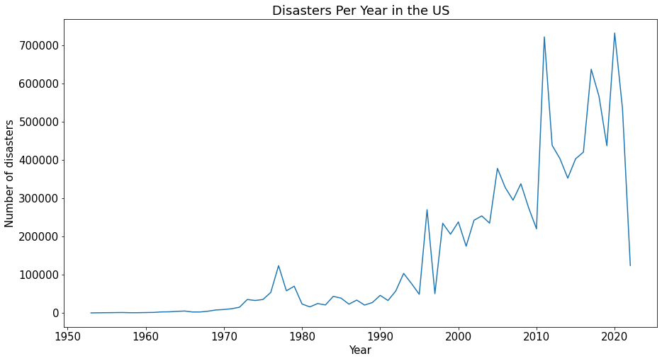

```python
# Plotting disasters per year
disasters_per_year = top_10_disastersData.groupby(['year']).sum()
disasters_per_year = disasters_per_year.reset_index()

# Updating plot size and the font
plt.rcParams["figure.figsize"] = (15,8)
plt.rcParams.update({'font.size': 15})

# Defining the x and y axis variables
X = disasters_per_year['year']
Y = disasters_per_year['disasterNumber']

# Creating the plot
fig, ax = plt.subplots()
ax.ticklabel_format(style='plain')
plt.plot(X,Y)

plt.title("Disasters Per Year in the US")
plt.xlabel("Year")
plt.ylabel("Number of disasters")
```

Notice that 2011 and 2020 have the highest number of disasters per year. We see that overall there is a positive trend between number of disasters and year in the US.

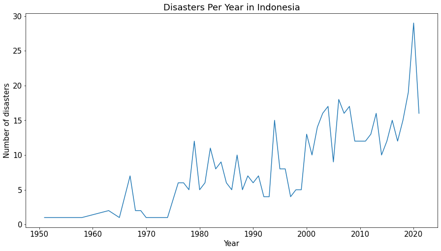

```python
# Plotting disasters per year for indonesia
idn_disasters_per_year = indonesia_disasters.groupby(['Year']).count()
idn_disasters_per_year = idn_disasters_per_year.reset_index()

# Defining the x and y axis variables
X = idn_disasters_per_year['Year']
Y = idn_disasters_per_year['Disaster Type']

# Creating the plot
fig, ax = plt.subplots()
ax.ticklabel_format(style='plain')
plt.plot(X,Y)
plt.title("Disasters Per Year in Indonesia")
plt.xlabel("Year")
plt.ylabel("Number of disasters")
```

It is important to note that Indonesia is much smaller than the US in terms of geographical size, which would explain why Indonesia sees fewer disasters. The difference can also be attributed to the fact that Fema(US data) has collected a lot more disaster data, mainly because it is the government agency responsible in the US, while the Indonesia disaster data was put together by a data scientist on Kaggle.

### **What is the trend for each disaster type?**

Lets examine the disaster trend plots made above in more detail by looking at the types of disasters that consitute the number of disasters per year.

Because there are 22 different types of disasters labeled in the FEMA dataset, lets just take a look at the top 10 disasters for the US.

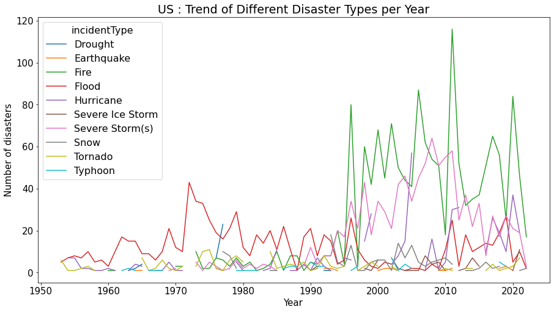

```python
fig, ax = plt.subplots(figsize=(15,8))
plt.rcParams.update({'font.size': 16})

# Grouping top 10 disasters by year and incident type and counting their occurence per year
groups = top_10_disastersData.groupby(['year','incidentType']).count()

# Unstacking the groups by an arbitrary column because the result was reflected all columns and creating plot
groups['id'].unstack().plot(ax=ax)

# Adding graph labels
plt.title("US : Trend of Different Disaster Types per Year")
plt.xlabel("Year")
plt.ylabel("Number of disasters")
```

We notice that there is an drastic increase in fires, severe storms, and hurricanes after 1990, however fires have been occuring the most. Floods do not have an increasing or decreasing trend except for between 1996 to 2008.

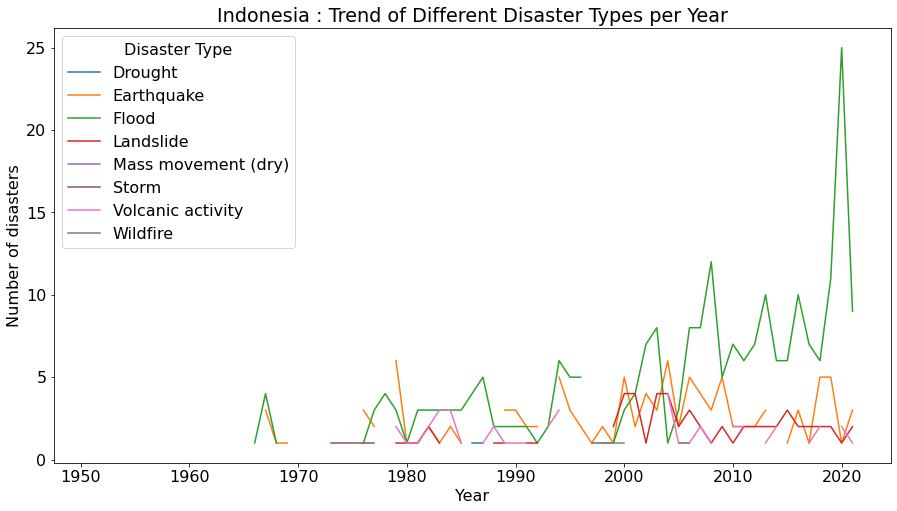

```python
fig, ax = plt.subplots(figsize=(15,8))

# Grouping top 10 disasters by year and disaster type and counting their occurence per year
groups = indonesia_disasters.groupby(['Year','Disaster Type']).count()

# Unstacking the groups by an arbitrary column because the result was reflected all columns and creating plot
indonesia_disasters.groupby(['Year','Disaster Type']).count()['Event Name'].unstack().plot(ax=ax)

# Adding graph labels
plt.title("Indonesia : Trend of Different Disaster Types per Year")
plt.xlabel("Year")
plt.ylabel("Number of disasters")
```

Looking at Indonesia's disaster types trend, notice that there has been an increase in floods after 2000. Occurence of landslides and earthquakes, if they occur, happen consistently per year with no increase of decrease in trend.

What we can make out from these two graphs in both countries the number of certain disasters started to increase per year after 2000. For the US, it is fires, severe storms, and hurricanes, and for Indonesia, it is floods.

## What kind of disasters does the east coast experience vs. the west coast in the US?

The US covers a large geographical area which means that certain regions could be more prone to certain disasters than others. I will look at East and West coast to see which disasters occur in which area.

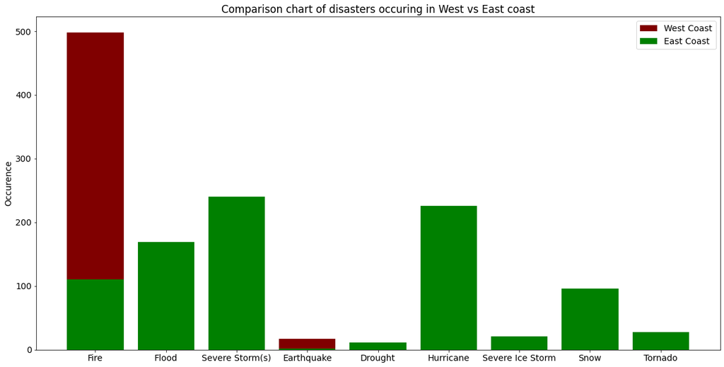

```python
# Looking at the top 10 types of disasters
data = top_10_disastersData

# Getting the disasters that occur in states bordering Pacific Ocean
west_coast_major_disasters = data.loc[(data['stateCode'] == 'CA') | (data['stateCode'] == 'OR') | (data['stateCode'] == 'WA')]
wc_counts = west_coast_major_disasters['incidentType'].value_counts()
wc_disastorTypes = list(wc_counts.index)
wc_countsArr = list(wc_counts.array)

# Getting the disasters that occur in states bordering Atlantic Ocean
east_coast_major_disasters = data.loc[(data['stateCode'] == 'ME') | (data['stateCode'] == 'VT') | (data['stateCode'] == 'NH') | (data['stateCode'] == 'CT') | (data['stateCode'] == 'MA') | (data['stateCode'] == 'RI') | (data['stateCode'] == 'NY') | (data['stateCode'] == 'MD') | (data['stateCode'] == 'NJ') | (data['stateCode'] == 'PA') | (data['stateCode'] == 'VA') | (data['stateCode'] == 'NC') | (data['stateCode'] == 'SC') | (data['stateCode'] == 'GA') | (data['stateCode'] == 'FL')]
ec_counts = east_coast_major_disasters['incidentType'].value_counts()
ec_disastorTypes = list(ec_counts.index)
ec_countsArr = list(ec_counts.array)

# Drawing the bar chart
plt.rcParams["figure.figsize"] = (20,10)
plt.rcParams.update({'font.size': 14})
fig, axs = plt.subplots()
axs.bar(wc_disastorTypes, wc_countsArr, color='maroon', label = 'West Coast')
axs.bar(ec_disastorTypes, ec_countsArr, color = 'green', label = 'East Coast')
axs.set_ylabel('Occurence')
axs.set_title('Comparison chart of disasters occuring in West vs East coast')
axs.legend()
```

We also want to analyze in-depth the top disasters of each state, particularly ones that were declared a federal emergencies and the ones occuring after 2010.

```python
# Grouping disasters by federal emergencies and year after 2020
states_disasters = data[(data['declarationType'] == 'Emergency') & (data['year'] > 2010)]
states_disasters = states_disasters[['stateName','incidentType']].groupby('stateName').describe()
states_disasters
```

| stateName | incidentType count | incidentType unique | incidentType top | incidentType freq |
| --- | --- | --- | --- | --- |
| Alabama | 5 | 2 | Hurricane | 4 |
| Alaska | 1 | 1 | Earthquake | 1 |
| American Samoa | 1 | 1 | Hurricane | 1 |
| Arkansas | 2 | 2 | Flood | 1 |
| California | 5 | 2 | Fire | 4 |
| Colorado | 1 | 1 | Flood | 1 |
| Connecticut | 6 | 2 | Hurricane | 4 |
| Delaware | 2 | 1 | Hurricane | 2 |
| District of Columbia | 2 | 1 | Hurricane | 2 |
| Florida | 12 | 2 | Hurricane | 11 |
| Georgia | 5 | 2 | Hurricane | 4 |
| Hawaii | 3 | 1 | Hurricane | 3 |
| Illinois | 1 | 1 | Tornado | 1 |
| Kansas | 2 | 2 | Flood | 1 |
| Kentucky | 1 | 1 | Tornado | 1 |
| Louisiana | 12 | 3 | Hurricane | 8 |
| Maryland | 2 | 1 | Hurricane | 2 |
| Massachusetts | 4 | 2 | Hurricane | 3 |
| Mississippi | 8 | 2 | Hurricane | 7 |
| Missouri | 3 | 2 | Flood | 2 |
| Nebraska | 1 | 1 | Flood | 1 |
| New Hampshire | 3 | 2 | Hurricane | 2 |
| New Jersey | 3 | 1 | Hurricane | 3 |
| New York | 5 | 2 | Hurricane | 4 |
| North Carolina | 5 | 1 | Hurricane | 5 |
| North Dakota | 2 | 1 | Flood | 2 |
| Northern Mariana Islands | 4 | 1 | Typhoon | 4 |
| Ohio | 1 | 1 | Severe Storm(s) | 1 |
| Oklahoma | 3 | 3 | Severe Storm(s) | 1 |
| Oregon | 1 | 1 | Fire | 1 |
| Pennsylvania | 4 | 3 | Hurricane | 2 |
| Puerto Rico | 7 | 3 | Hurricane | 5 |
| Rhode Island | 3 | 1 | Hurricane | 3 |
| South Carolina | 6 | 3 | Hurricane | 4 |
| Tennessee | 2 | 2 | Flood | 1 |
| Texas | 3 | 2 | Hurricane | 2 |
| Vermont | 2 | 1 | Hurricane | 2 |
| Virgin Islands of the U.S. | 4 | 1 | Hurricane | 4 |
| Virginia | 3 | 1 | Hurricane | 3 |
| Washington | 2 | 1 | Fire | 2 |
| West Virginia | 2 | 2 | Hurricane | 1 |

We can now see which disasters each states sees the most. It is also easier to distinguish between which states get hurricanes and which get severe storms.

## **How might GDP differ based on the disasters occuring in the US and Indonesia?**

We are trying to explore the impact natural disasters have on the economy. A good measure for economic growth is GDP(gross domestic product). Here we are going to look at GDP growth per year and the number of disasters occuring. We want to see if there is any pattern, correlation, or any kind of relation. To do so, we will create a line plot of both the gdp and disasters occuring over the years and examine the trend.

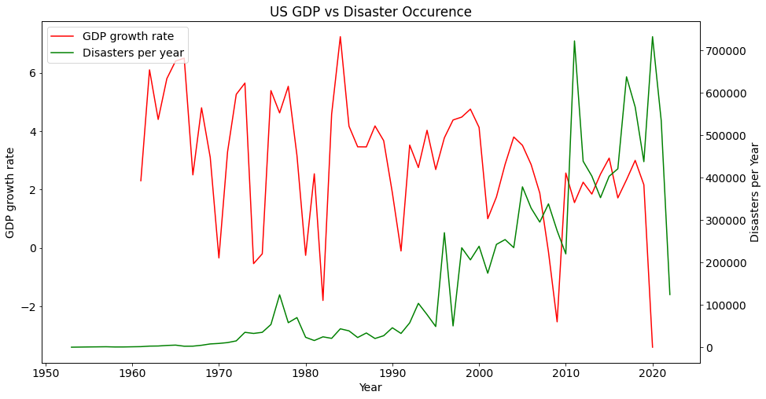

```python
# US's GDP vs Disaster Graph

# Getting GDP data after 1950
gdp_data_1950 = us_gdp_data[us_gdp_data['year'] > 1950]

# Defining X and Y values
X = gdp_data_1950['year']
Y = gdp_data_1950['value']

# Defining the disasters per year
disasters_per_year = data.groupby(['year']).sum()
disasters_per_year=disasters_per_year.reset_index()

# Creating the GDP Plot
plt.rcParams["figure.figsize"] = (15,8)
ax1 = plt.subplot()
l1, = ax1.plot(X,Y, color='red')
ax1.set_xlabel('Year')
ax1.set_ylabel('GDP growth rate')

# Creating the disastors per year plot
ax2 = ax1.twinx()
ax2.set_xlabel('Year')
ax2.set_ylabel('Disasters per Year')
l2, = ax2.plot(disasters_per_year['year'],disasters_per_year['disasterNumber'], color='green')
plt.legend([l1, l2], ["GDP growth rate", "Disasters per year"])
plt.title("US GDP vs Disaster Occurence")
```

It hard to make out any relation between the two variables(disasters and GDP). Before 2000, there seemed to be gdp growth with a few downward spikes and no disasters, but after 2000, there is drop in gdp growth in 2009 and 2020 and gdp growth overall isn't as high as it used to be before. After 2000s, we also notice the number of disasters increasing drastically. Could the two be related in any way?

We had [the Great Recession](https://www.federalreservehistory.org/essays/great-recession-and-its-aftermath) that occured from 2007-2009, caused by a subprime mortgage crisis and the bursting of the housing bubble. We speculate this to be the downward spike in gdp we see in 2009. The 2020 downward spike was a result of Covid.

In all, we do not see any relation between disaster occurences per year and GDP growth looking at just this graph.

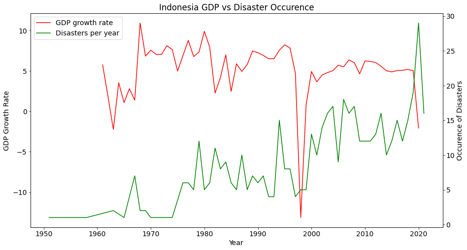

```python
# Indonesia's GDP vs Disasters graph

# Defining X and Y values
X1 = id_gdp_data['year']
Y1 = id_gdp_data['value']

# Plotting disasters per year
X2 = idn_disasters_per_year['Year']
Y2 = idn_disasters_per_year['Disaster Type']

# Creating the GDP Plot
plt.rcParams["figure.figsize"] = (15,8)
ax1 = plt.subplot()
l1, = ax1.plot(X1,Y1, color='red')
ax1.set_xlabel('Year')
ax1.set_ylabel('GDP Growth Rate')

# Creating the disastors per year plot
ax2 = ax1.twinx()
ax2.set_xlabel('Year')
ax2.set_ylabel('Occurence of Disasters')
l2, = ax2.plot(X2,Y2, color='green')
plt.legend([l1, l2], ["GDP growth rate", "Disasters per year"])
plt.title("Indonesia GDP vs Disaster Occurence")
```

Looking at both the US and Indonesia, we do not get a good understanding of how occurence of natural disasters might look alongside gdp growth. It is important to consider that we have been looking at the GDP of an entire country. If one region of a country is affected, maybe it does not impact the overall gdp of the country. Location might matter, and that is what we will explore next.

### **What does GDP vs disaster occurence look like for some US states?**

Because we have disaster and gdp data for US states available to us, we can compare gdp and disaster occurence per year. By focusing on smaller parts of the country, maybe we can examine the statewide economic impact of disasters. We will be looking at two states in particular : Texas and Louisianna. They both border the Gulf of Mexico and looking at the major disasters of each state table, we find that they both experience hurricanes which makes sense because the Gulf of Mexico is said to have the highest probability for hurricane tracks. Being neighboring states, we can take a look at how disasters might affect their real gdp. Note that we do not have GDP growth data on the states, but instead [Real GDP](https://www.investopedia.com/terms/r/realgdp.asp) data.

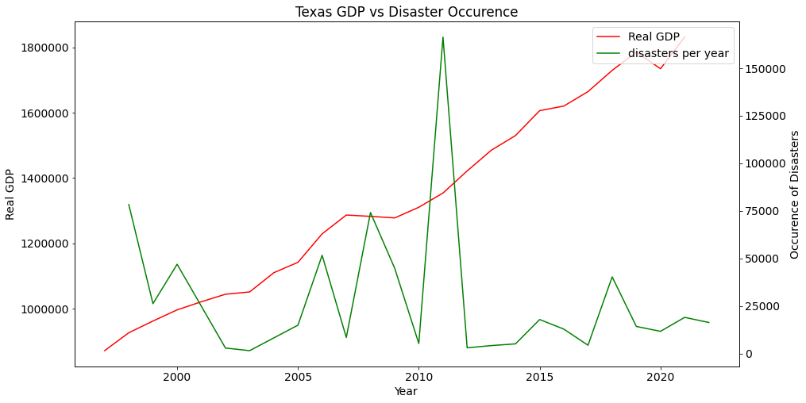

```python
# Texas gdp and disasters plot
data = top_10_disastersData

# Filtering dataframe for texas
texas_disasters = data[(data['year'] > 1997) & (data['stateCode'] == 'TX')]

# Gathering all the disasters that occured in a year
texas_disasters_per_year = texas_disasters.groupby(['year']).sum()
texas_disasters_per_year = texas_disasters_per_year.reset_index()

# Creating our two variables for disaster plot
X_disasters = texas_disasters_per_year['year']
Y_disasters = texas_disasters_per_year['disasterNumber']

# Creating our two variables for gdp plot
texas_gdp_data = states_gdp[states_gdp['GeoName'] == "Texas"]
X_gdp = texas_gdp_data['year']
Y_gdp = texas_gdp_data['value']

# Creating the GDP vs disaster Plot
plt.rcParams["figure.figsize"] = (15,8)
ax1 = plt.subplot()
l1, = ax1.plot(X_gdp,Y_gdp, color='red')
ax1.set_xlabel('Year')
ax1.set_ylabel('Real GDP')

ax2 = ax1.twinx()
l2, = ax2.plot(X_disasters,Y_disasters, color='green')
ax1.ticklabel_format(style='plain')
ax2.ticklabel_format(style='plain')
ax2.set_xlabel('Year')
ax2.set_ylabel('Occurence of Disasters')

plt.legend([l1, l2], ["Real GDP", "disasters per year"])
plt.title("Texas GDP vs Disaster Occurence")
```

Gdp growth is increasing and we don't see much relation between GDP and the disasters occuring per year. Notice that I have plotted real GDP so when we look at its slope, we only make note of it being a Gdp growth rate of above 0. Even in 2011 when there was the [Texas Wildfire](https://en.wikipedia.org/wiki/2011_Texas_wildfires), it doesn't seem to have affected the slope of GDP.

Lets now look at Louisiana.

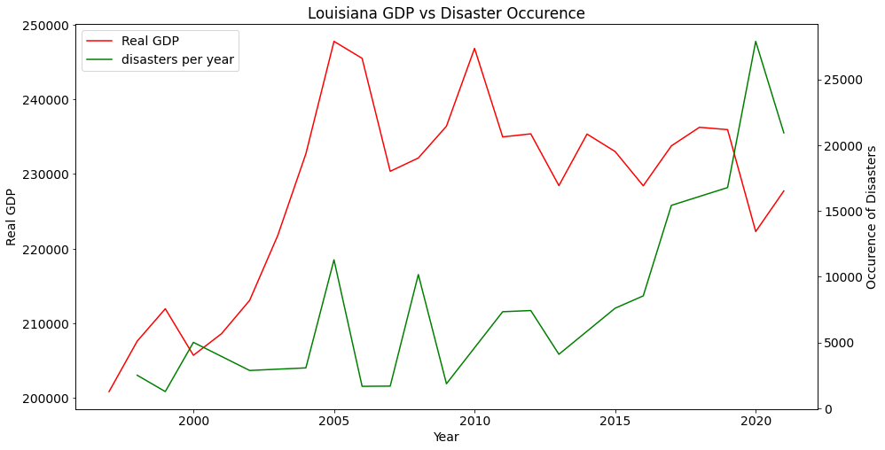

```python
# Filtering Lousiana disasters
lousiana_disasters = data[(data['year'] > 1997) & (data['stateCode'] == 'LA')]
lousiana_disasters_per_year = lousiana_disasters.groupby(['year']).sum()
lousiana_disasters_per_year = lousiana_disasters_per_year.reset_index()

# Setting our x and y variables for the disasters plot
X_disasters = lousiana_disasters_per_year['year']
Y_disasters = lousiana_disasters_per_year['disasterNumber']

# Setting our x and y variables for the gdp plot
louisiana_gdp_data = states_gdp[states_gdp['GeoName'] == "Louisiana"]
X_gdp = louisiana_gdp_data['year']
Y_gdp = louisiana_gdp_data['value']
texas_gdp_data['year']

# Creating the GDP vs disaster Plot
ax1 = plt.subplot()
l1, = ax1.plot(X_gdp,Y_gdp, color='red')
ax1.set_xlabel('Year')
ax1.set_ylabel('Real GDP')

ax2 = ax1.twinx()
l2, = ax2.plot(X_disasters,Y_disasters, color='green')
ax2.set_xlabel('Year')
ax2.set_ylabel('Occurence of Disasters')

plt.legend([l1, l2], ["Real GDP", "disasters per year"])
plt.title("Louisiana GDP vs Disaster Occurence")
```

Texas and Lousiana are economically different. Texas's economy is second largest by GDP in the US while Louisiana does not have such a large economy. It seems that there may be some relation between Louisiana's economy and the disasters it has faced. We will explore this relation a lot more in the next part.

## **Exploring duration of a disaster vs GDP growth rate**

```python
warnings.simplefilter(action="ignore", category=SettingWithCopyWarning)
# Pairing each disaster with state gdp 1 year later

# Creating new column in us disasters dataframe
top_10_disastersData['futureGDP'] = pd.Series(dtype='float')
top_10_disastersData['currentGDP'] = pd.Series(dtype='float')

# Looping over the rows and adding the respective gdp 1 year later
for index, row in fema_data.iterrows():
  state = row['stateName']
  year = row['year'] - 1

  # Getting current GDP
  currentGDP = states_gdp[(states_gdp['GeoName'] == state) & (states_gdp['year'] == year)]
  currentGDP = currentGDP['value']

  # Getting GDP 1 year later
  year = row['year']
  gdp_1_year_later = states_gdp[(states_gdp['GeoName'] == state) & (states_gdp['year'] == year)]
  gdp_1_year_later = gdp_1_year_later['value']

  # if gdp_2_years_later == nan:
  #   data['GDP 2 years later'][index] = np.nan
  # else:
  top_10_disastersData['futureGDP'][index] = gdp_1_year_later
  top_10_disastersData['currentGDP'][index] = currentGDP


# We don't have gdp data for some American territories and for 2020, so I'm dropping the null valued gdp rows
states_gdp = states_gdp.dropna()
top_10_disastersData = top_10_disastersData.dropna()
```

```python
top_10_disastersData[['futureGDP','currentGDP']].head(5)
```

|  | futureGDP | currentGDP |
| --- | --- | --- |
| 2 | 89032.0 | 89151.4 |
| 3 | 912966.2 | 881539.2 |
| 4 | 912966.2 | 881539.2 |
| 5 | 233774.4 | 228428.5 |
| 6 | 1664218.5 | 1619954.2 |

Now that we have our currentGDP and futureGDP column, we will be adding in a column for the duration of a disaster. This will help us create plots that will relate the duration of a disaster with GDP growth rate. Essentially, what we are asking is whether the duration of a disaster has some affect on the economy. By using duration, we can measure impact of a disaster. We make the assumption that disasters that last longer do more damage.

```python
# We will be dropping columns that don't have an actual end date
top_10_disastersData = top_10_disastersData[top_10_disastersData['incidentEndDate'] != np.datetime64('1000-04-20 00:00:00+00:00')]

# Calculating duration of disasters
top_10_disastersData['incidentEndDate'] = pd.to_datetime(top_10_disastersData['incidentEndDate'])
top_10_disastersData['duration'] = top_10_disastersData['incidentEndDate'] - top_10_disastersData['incidentBeginDate']
top_10_disastersData['duration'] = [x.days for x in top_10_disastersData['duration']]

# Calculating gdp growth rate
top_10_disastersData['GDP_growth_rate'] = (top_10_disastersData['futureGDP'] - top_10_disastersData['currentGDP']) / top_10_disastersData['currentGDP']
top_10_disastersData['GDP_growth_rate'].head(5)
```

```
2   -0.001339
3    0.035650
4    0.035650
5    0.023403
6    0.027324
Name: GDP_growth_rate, dtype: float64
```

Now we will create some plots. First we will plot the duration of a disaster vs GDP for the state it occured in.

```
[Text(0.5, 1.0, 'Duration of Disaster(days) vs GDP')]
```

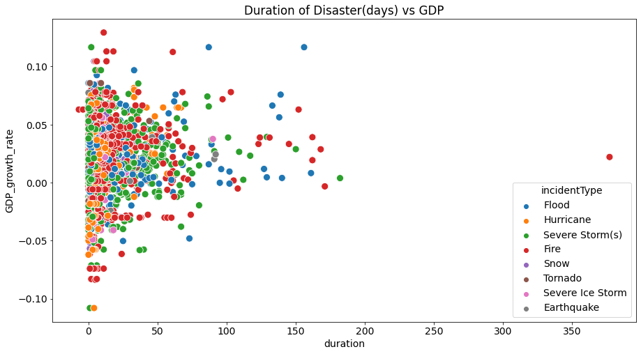

```python
s = sns.scatterplot(
    data=top_10_disastersData,
    x="duration",
    y=top_10_disastersData['GDP_growth_rate'],
    s = 100,
    hue='incidentType')

s.set(title = "Duration of Disaster(days) vs GDP")
```

Here we have plotted our top disasters with their duration vs. gdp growth rate. It's hard to make out any kind of relation so lets create separate plots for hurricane, severe storms(s), and fire as we found these to be the most common types of disasters .

```
[Text(0.5, 1.0, 'Hurricanes : duration(days) vs gdp')]
```

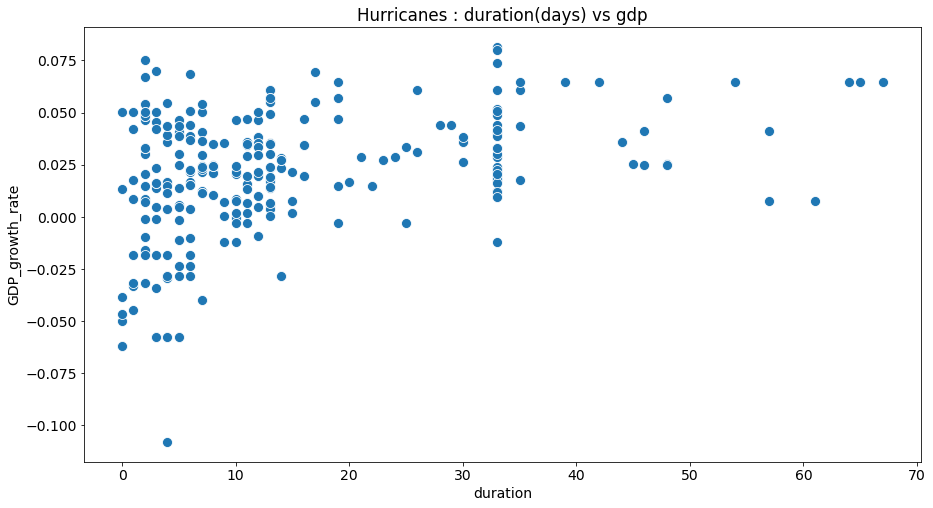

```python
# Creating scatterplot for hurricanes
p1= sns.scatterplot(data=top_10_disastersData[top_10_disastersData['incidentType'] == 'Hurricane'],
                x="duration",
                y=top_10_disastersData['GDP_growth_rate'],
                s = 100)
p1.set(title = "Hurricanes : duration(days) vs gdp")
```

```
[Text(0.5, 1.0, 'Severe Storm(s) : duration(days) vs gdp')]
```

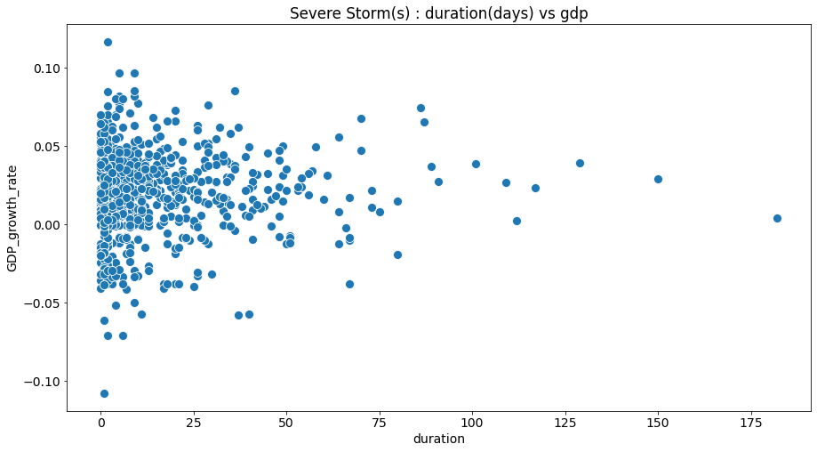

```python
# Creating scatterplot for severe storms
p2 = sns.scatterplot(data=top_10_disastersData[top_10_disastersData['incidentType'] == 'Severe Storm(s)'],
                x="duration",
                y=top_10_disastersData['GDP_growth_rate'],
                s = 100)
p2.set(title = "Severe Storm(s) : duration(days) vs gdp")
```

```
[Text(0.5, 1.0, 'Fires : duration(days) vs gdp')]
```

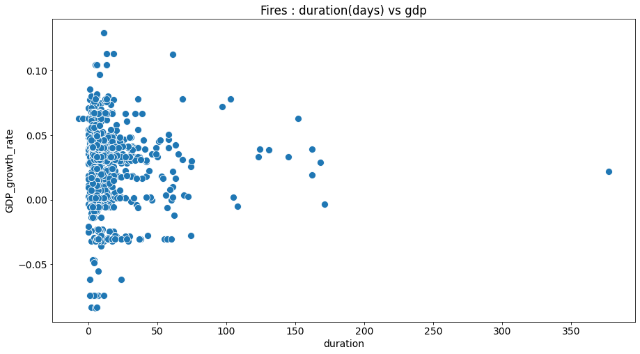

```python
# Creating scatterplot for fires
p3 = sns.scatterplot(data=top_10_disastersData[top_10_disastersData['incidentType'] == 'Fire'],
                x="duration",
                y=top_10_disastersData['GDP_growth_rate'],
                s = 100)

p3.set(title = "Fires : duration(days) vs gdp")
```

From the severe storm and fire plots above, we notice that disasters occuring less than 50 days have their GDP's ranging from negative growth rates to positive. As the duration increases, the GDP seems to center around 0 and 0.05 for all three of the plots.

For hurricanes, it looks like as the duration is longer the GDP growth is slightly higher. For severe storms, the GDP growth is mainly centered around 0 as duration increases and for fires, the GDP growth is more spread out even when duration increases.

From our previous data exploration with Texas and Louisiana, we noticed how disaster affect different states beceause their economies are vastly different. We can explore this further by plotting duration vs GDP for different states. We will also reference the the popular disasters per state table and the barchart comparing east and west coast states to figure out which disasters we may want to plot.

### Florida disaster duration vs GDP

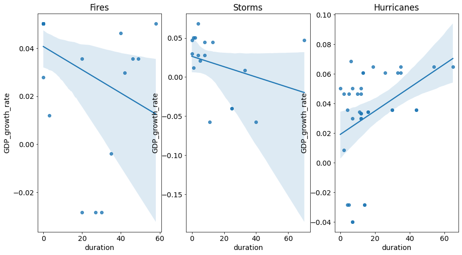

```python
fig, axs = plt.subplots(ncols=3)

# Plotting Florida fires
florida_fires = sns.regplot(
    ax=axs[0],
    x="duration",
    y="GDP_growth_rate",
    data=top_10_disastersData[(top_10_disastersData["stateCode"] == 'FL') & (top_10_disastersData["incidentType"] == 'Fire')])

florida_fires.set_title('Fires')

# Plotting Florida severe storms
florida_storms = sns.regplot(
    ax=axs[1],
    x="duration",
    y="GDP_growth_rate",
    data=top_10_disastersData[(top_10_disastersData["stateCode"] == 'FL') & (top_10_disastersData["incidentType"] == 'Severe Storm(s)')])
florida_storms.set_title('Storms')

# Plotting Florida Hurricanes
florida_hurricanes = sns.regplot(
    ax=axs[2],
    x="duration",
    y="GDP_growth_rate",
    data=top_10_disastersData[(top_10_disastersData["stateCode"] == 'FL') & (top_10_disastersData["incidentType"] == 'Hurricane')])
florida_hurricanes.set_title('Hurricanes')
```

### California disaster duration vs gdp

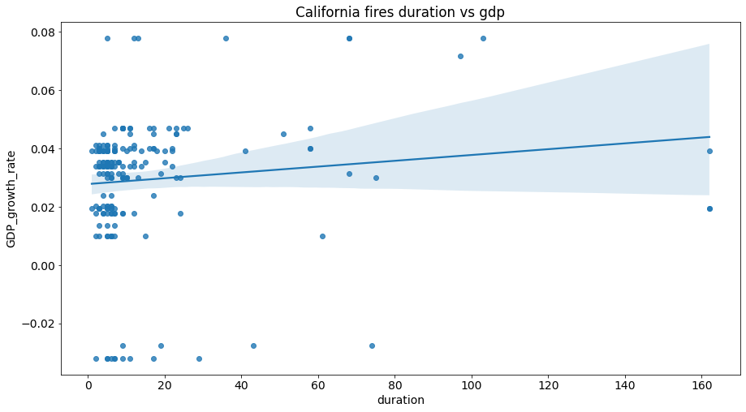

```python
# Plotting California fires
CA_fires = sns.regplot(
    x="duration",
    y="GDP_growth_rate",
    data=top_10_disastersData[(top_10_disastersData["stateCode"] == 'CA') & (top_10_disastersData["incidentType"] == 'Fire')])
CA_fires.set_title('California fires duration vs gdp')
```

### North Carolina disaster duration(days) vs gdp

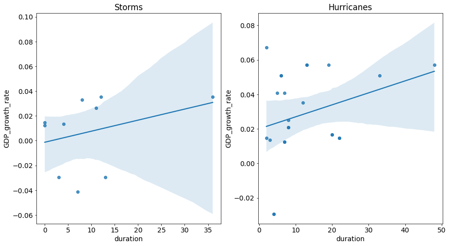

```python
fig, axs = plt.subplots(ncols=2)

# Plotting Florida severe storms
nc_storms = sns.regplot(
    ax=axs[0],
    x="duration",
    y="GDP_growth_rate",
    data=top_10_disastersData[(top_10_disastersData["stateCode"] == 'NC') & (top_10_disastersData["incidentType"] == 'Severe Storm(s)')])
nc_storms.set_title('Storms')

# Plotting Florida Hurricanes
nc_hurricanes = sns.regplot(
    ax=axs[1],
    x="duration",
    y="GDP_growth_rate",
    data=top_10_disastersData[(top_10_disastersData["stateCode"] == 'NC') & (top_10_disastersData["incidentType"] == 'Hurricane')])
nc_hurricanes.set_title('Hurricanes')
```

Looking at the three plots on Florida, California, and North Carolina, we can see that state is an important variable to consider when comparing disaster duration with gdp growth rate. For Florida, we can make out some kind of positive linear relation for duration of hurricanes and gdp growth, while for California fires, there doesn't seem to be much relation as the data points are scattered. For North Carolina, we notice that there might be some kind of linear relation for hurricanes. We can explore these linear relations further by conducting a hypothesis test in the next section.

# **Linear Regression and Hypothesis Testing**

In this part of the tutorial, we will be do a hypothesis test to test whether there is a linear relation between duration of a disaster and gdp growth rate. We will be using [statsmodels](https://www.statsmodels.org/devel/gettingstarted.html) to create our linear regression models and conduct our hypothesis test.

```python
import statsmodels.formula.api as smf
```

*Step 1 :* We must set our null and alternate hypothesis. Because we want to prove that duration does linearly affect gdp growth, our null hypothesis is that it doesn't. In other words, the slope of the regression line is 0 and we want to prove that it is non-zero for the regression to be linear.

> $H_0$ Null Hypothesis : Duration of a disaster does not linearly affect gdp growth rate.

> $H_1$ Alternate Hypothesis : Duration of a disaster does linearly affect gdp growth rate

*Step 2 :* We must decide on a significance level($\alpha$).

> $\alpha = 0.05$

```python
# fitting statistical model using R-style formula. More info : https://www.statsmodels.org/devel/example_formulas.html?highlight=formula
model = smf.ols(formula='GDP_growth_rate ~ duration', data = top_10_disastersData)
results = model.fit()
results.summary()
```

OLS Regression Results

| Dep. Variable: | GDP_growth_rate | R-squared: | 0.002 |
| --- | --- | --- | --- |
| Model: | OLS | Adj. R-squared: | 0.002 |
| Method: | Least Squares | F-statistic: | 5.128 |
| Date: | Sat, 14 May 2022 | Prob (F-statistic): | 0.0236 |
| Time: | 01:10:34 | Log-Likelihood: | 5514.8 |
| No. Observations: | 2551 | AIC: | -1.103e+04 |
| Df Residuals: | 2549 | BIC: | -1.101e+04 |
| Df Model: | 1 |  |  |
| Covariance Type: | nonrobust |  |  |

|  | coef | std err | t | P>\|t\| | [0.025 | 0.975] |
| --- | --- | --- | --- | --- | --- | --- |
| Intercept | 0.0215 | 0.001 | 32.540 | 0.000 | 0.020 | 0.023 |
| duration | 5.778e-05 | 2.55e-05 | 2.264 | 0.024 | 7.74e-06 | 0.000 |

| Omnibus: | 131.485 | Durbin-Watson: | 1.041 |
| --- | --- | --- | --- |
| Prob(Omnibus): | 0.000 | Jarque-Bera (JB): | 242.720 |
| Skew: | -0.385 | Prob(JB): | 1.97e-53 |
| Kurtosis: | 4.301 | Cond. No. | 31.0 |

Warnings:  
[1] Standard Errors assume that the covariance matrix of the errors is correctly specified.

Next, we can try considering different disaster types as the duration of a disaster depends on the kind of disaster. So we are going to add an interaction term: disasterType.

Linear Regression for Different Disaster Types

To learn more about how to use interaction terms with statsmodels: https://www.statsmodels.org/devel/example_formulas.html

```python
model2 = smf.ols(formula='GDP_growth_rate ~ duration * C(incidentType)', data=top_10_disastersData)
results = model2.fit()
print(results.summary())
```

```
                            OLS Regression Results
==============================================================================
Dep. Variable:        GDP_growth_rate   R-squared:                       0.044
Model:                            OLS   Adj. R-squared:                  0.039
Method:                 Least Squares   F-statistic:                     7.861
Date:                Sat, 14 May 2022   Prob (F-statistic):           1.38e-17
Time:                        01:24:47   Log-Likelihood:                 5570.2
No. Observations:                2551   AIC:                        -1.111e+04
Df Residuals:                    2535   BIC:                        -1.101e+04
Df Model:                          15
Covariance Type:            nonrobust
================================================================================================================
                                                   coef    std err          t      P>|t|      [0.025      0.975]
----------------------------------------------------------------------------------------------------------------
Intercept                                        0.0160      0.009      1.685      0.092      -0.003       0.035
C(incidentType)[T.Fire]                          0.0118      0.010      1.238      0.216      -0.007       0.031
C(incidentType)[T.Flood]                        -0.0015      0.010     -0.152      0.880      -0.021       0.018
C(incidentType)[T.Hurricane]                    -0.0074      0.010     -0.761      0.447      -0.027       0.012
C(incidentType)[T.Severe Ice Storm]              0.0014      0.010      0.136      0.892      -0.019       0.022
C(incidentType)[T.Severe Storm(s)]               0.0016      0.010      0.172      0.863      -0.017       0.020
C(incidentType)[T.Snow]                         -0.0008      0.010     -0.077      0.939      -0.021       0.019
C(incidentType)[T.Tornado]                       0.0072      0.011      0.686      0.493      -0.013       0.028
duration                                      5.099e-05      0.000      0.224      0.823      -0.000       0.000
duration:C(incidentType)[T.Fire]             -8.575e-05      0.000     -0.372      0.710      -0.001       0.000
duration:C(incidentType)[T.Flood]             9.763e-05      0.000      0.415      0.678      -0.000       0.001
duration:C(incidentType)[T.Hurricane]            0.0007      0.000      2.833      0.005       0.000       0.001
duration:C(incidentType)[T.Severe Ice Storm]  4.473e-05      0.000      0.127      0.899      -0.001       0.001
duration:C(incidentType)[T.Severe Storm(s)]   6.455e-06      0.000      0.028      0.978      -0.000       0.000
duration:C(incidentType)[T.Snow]                 0.0009      0.001      1.517      0.129      -0.000       0.002
duration:C(incidentType)[T.Tornado]              0.0003      0.000      0.555      0.579      -0.001       0.001
==============================================================================
Omnibus:                      147.158   Durbin-Watson:                   1.068
Prob(Omnibus):                  0.000   Jarque-Bera (JB):              293.866
Skew:                          -0.400   Prob(JB):                     1.54e-64
Kurtosis:                       4.458   Cond. No.                     1.48e+03
==============================================================================

Warnings:
[1] Standard Errors assume that the covariance matrix of the errors is correctly specified.
[2] The condition number is large, 1.48e+03. This might indicate that there are
strong multicollinearity or other numerical problems.
```

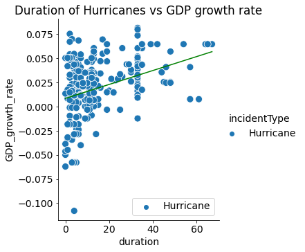

```python
# Filtering data for just hurricanes
hurricanes = top_10_disastersData[top_10_disastersData['incidentType'] == 'Hurricane']

# Creating regression line: y = intercept + (duration:incidentType[T.Hurricane]) * duration
hurricanes['y_line'] = results.params['Intercept'] + results.params['C(incidentType)[T.Hurricane]'] + results.params['duration:C(incidentType)[T.Hurricane]']*hurricanes['duration']

# Creating scatterplot of hurricane with regression line
s = sns.relplot(
    kind='scatter',
    x="duration",
    y=top_10_disastersData['GDP_growth_rate'],
    s=100,
    hue="incidentType",
    data=hurricanes).set(title="")
s = sns.lineplot(data=hurricanes, x = 'duration', y ='y_line', color='g')
s.set_title("Duration of Hurricanes vs GDP growth rate")
```

We do notice a slight positive linear relation. It seems a bit odd that the longer a hurricane, the less damaging it is on the economy. The fema disaster data we have used hurricanes declared as major disasters and those as federal emergencies. It could be that different states are impacted differently. Next, we could try adding state as an interaction variable as we know from our previous data exploration that each state recovers differently from disasters. For instance, we saw in our data analysis how Texas and Louisiana were affected by disasters. Texas didn't seem take a hit to their GDP, while Louisiana did.

Also we will filter our incident type to include just the top 3 disasters: fires, hurricanes, and severe-storms to keep our analysis simpler.

```python
# Filtering disaster data to include just fires, hurricanes, and severe storms
data = top_10_disastersData[(top_10_disastersData['incidentType'] == 'Fire') | (top_10_disastersData['incidentType'] == 'Hurricane') | (top_10_disastersData['incidentType'] == 'Severe Storm(s)')]

# Creating our model
model3 = smf.ols(formula='GDP_growth_rate ~ duration * C(incidentType) * C(stateName) ', data=data, missing = 'drop')
results = model3.fit()

# Printing just the significant p-values
pvalues = results.pvalues.copy(deep=True)
pvalues = pvalues.dropna()
print(pvalues[pvalues < 0.05])

# Printing OLS Regression Results
summary = results.summary()
print(summary.tables[0])
```

```
C(stateName)[T.Alaska]                                             0.003976
C(stateName)[T.Delaware]                                           0.000505
C(stateName)[T.Florida]                                            0.012888
C(stateName)[T.Massachusetts]                                      0.010461
C(stateName)[T.Michigan]                                           0.004937
C(stateName)[T.North Dakota]                                       0.000005
C(stateName)[T.Pennsylvania]                                       0.029431
C(stateName)[T.Texas]                                              0.042572
C(incidentType)[T.Severe Storm(s)]:C(stateName)[T.Delaware]        0.034929
C(incidentType)[T.Hurricane]:C(stateName)[T.Hawaii]                0.014817
C(incidentType)[T.Severe Storm(s)]:C(stateName)[T.North Dakota]    0.000945
duration:C(stateName)[T.Delaware]                                  0.011701
duration:C(stateName)[T.Mississippi]                               0.047184
duration:C(stateName)[T.New York]                                  0.024791
duration:C(incidentType)[T.Hurricane]:C(stateName)[T.New York]     0.022559
dtype: float64
                            OLS Regression Results
==============================================================================
Dep. Variable:        GDP_growth_rate   R-squared:                       0.208
Model:                            OLS   Adj. R-squared:                  0.112
Method:                 Least Squares   F-statistic:                     2.160
Date:                Sat, 14 May 2022   Prob (F-statistic):           2.49e-18
Time:                        01:33:05   Log-Likelihood:                 4838.8
No. Observations:                2133   AIC:                            -9214.
Df Residuals:                    1901   BIC:                            -7899.
Df Model:                         231
Covariance Type:            nonrobust
==============================================================================
```

Our linear regression equation was extremely large so we filtered by the terms that had p-values less than 0.05. The R-squared is quite small and still doesn't explain the variation in the data well enough.

We notice that the two way interaction between the following are statistically significant and so we can reject the null hypothesis for the following:

- Delaware and Severe Storms
- Hawaii and Hurricanes
- North Dakota and Severe Storms
- Delaware and duration
- Mississippi and duration
- New York and duration

The three way interaction between New York, hurricane, and duration is also statistically significant and we can reject the null hypothesis here as well.

This means that state and type of disaster plays a role in determining the effect duration of a disaster may have on the GDP growth rate.

# Findings and Conclusion

Through our exploratory analysis some of our findings were :

- Natural disasters have been drastically rising since 2000
- In the US , there is an increase in the number of fires, hurricanes, and severe storms while in Indonesia there's been an increase in floods
- Natural disasters impacts the local economy of the US instead of the country's economy as a whole

After conducting the hypothesis test and linear regression we found there to be some kind of relation between the duration of a disaster and the effect on GDP growth in the US, however this relation depends on the US state and type of disaster.

These findings provoke new questions, such as what effect might the strength of a disaster have, or if state and federal funding is helping. The [Fema dataset](https://www.fema.gov/about/openfema/data-sets) consists of more than just disaster information. It has information on assistance programs, hazard mitigation, and emergency management. One can explore a lot more.

Disasters are increasing and are becoming much worse because of climate change. They aren't exactly easy to predict either so it is important to be prepared. I hope you found this tutorial useful in understanding the data science pipeline and are able to further this research.